# GEOG 3023 Lab 6

Sampling distributions and Confidence Intervals

Jason Lee

Complete all **10 Questions**, and submit the finished Rmd and knitted HTML file onto Canvas. Don’t forget to change name field in the beginning to your first and last name.

## Getting Started

### Load (and installing) required packages

```r
library(tidyverse)
# We need this package for function 'rep_sample_n()',
# install before use by uncommenting and running the line below
# install.packages('infer')
library(infer)
```

### Introduction

If you have access to data on an entire population, say the area of every house in Ames, Iowa, it’s straight forward to answer questions like, “What is the area of a typical house in Ames?” and “How much variation is there in areas of houses?”. If you have access to only a sample of the population, as is often the case, the task becomes more complicated. What is your best guess for the typical area if you only know the areas of several dozen houses? This sort of situation requires that you use your sample to make inference on what your population looks like.

### The Data

We’ll use real estate data from the city of Ames, Iowa. The details of every real estate transaction in Ames is recorded by the City Assessor’s office. Our particular focus for this lab will be all residential home sales in Ames between 2006 and 2010. This collection represents our population of interest. In this lab we would like to learn about these home sales by taking smaller samples from the full population. Let’s load the data.

```r
ames <- read.csv('data/ames.csv')
```

We see that there are quite a few variables in the data set, enough to do a very in-depth analysis. For this lab, we’ll restrict our attention to just two of the variables:

1. the above ground livable area of the house in square feet (`area`)
2. the sale price (`price`).

We can explore the distribution of areas of homes in the population of home sales visually and with summary statistics. Let’s first create a visualization, a histogram:

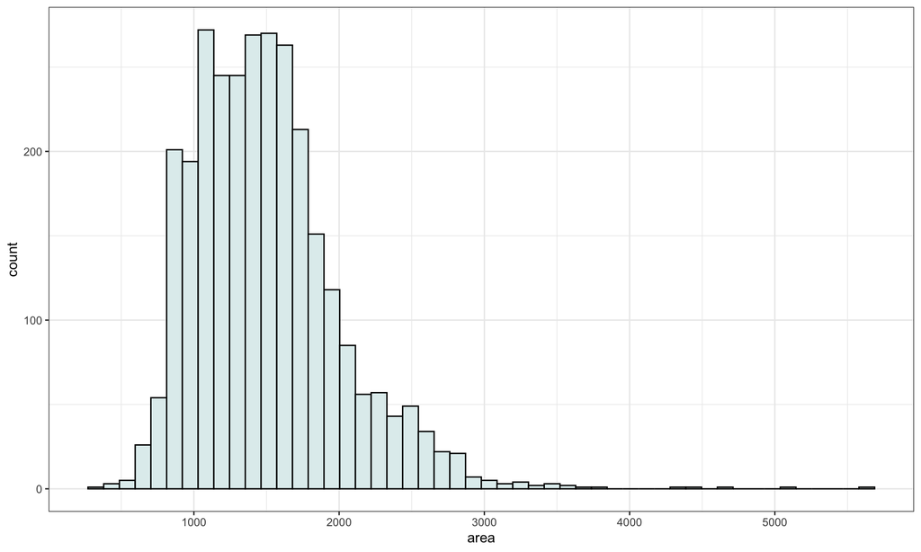

```r
ggplot(data=ames)+
  geom_histogram(aes(x=area),bins= 50,color="black",fill="azure2")+
  theme_bw()
```

Let’s also obtain some summary statistics. Note that we can do this using the`summarise` function. We can calculate as many statistics as we want using thisfunction, and just string along the results. Some of the functions below should be self explanatory (like `mean`, `median`, `sd`, `IQR`, `min`, and `max`). A new function here is the `quantile` function which we can use to calculate values corresponding to specific percentile cutoffs in the distribution. For example `quantile(x, 0.25)` will yield the cutoff value for the 25th percentile (Q1) in the distribution of x. Finding these values are useful for describing the distribution, as we can use them for descriptions like *“the middle 50% of the homes have areas between such and such square feet”*.

```r
ames %>%
  summarise(mu = mean(area), pop_med = median(area),
            sigma = sd(area), pop_iqr = IQR(area),
            pop_min = min(area), pop_max = max(area),
            pop_q1 = quantile(area, 0.25),  # first quartile, 25th percentile
            pop_q3 = quantile(area, 0.75))  # third quartile, 75th percentile
```

```
##        mu pop_med    sigma pop_iqr pop_min pop_max pop_q1  pop_q3
## 1 1499.69    1442 505.5089  616.75     334    5642   1126 1742.75
```

**Q1 (1 pt):** Which of the following is **false**?

- The distribution of areas of houses in Ames is unimodal and right-skewed.
- 50% of houses in Ames are larger than 1,499.69 square feet.
- The middle 50% of the houses range between approximately 1,126 square feet and 1,742.7 square feet.
- The IQR is approximately 616.7 square feet.
- The smallest house is 334 square feet and the largest is 5,642 square feet.

**Answer:** * 50% of houses in Ames are larger than 1,499.69 square feet.

### Setting a seed

We will take some random samples and calculate confidence based on these samples in this lab, which means you should set a seed on top of your lab. Setting a seed will cause R to sample the same sample each time you knit your document. This will make sure your results don’t change each time you knit, and it will also ensure reproducibility of your work (by setting the same seed it will be possible to reproduce your results). You can set a seed like this:

```r
set.seed(9102015) # make sure to change the seed
```

The number above is completely arbitrary. If you need inspiration, you can use your birthday or favorite number. You only need to do this once in your R Markdown document, but make sure it comes before sampling.

## The unknown sampling distribution

In this lab we have access to the entire population, but this is rarely the case in real life. Gathering information on an entire population is often extremely costly or impossible. Because of this, we often take a sample of the population and use that to understand the properties of the population.

If we were interested in estimating the mean living area in Ames based on a sample, we can use the following command to survey the population.

```r
samp1 <- ames %>%
  sample_n(size = 50)
```

This command collects a simple random sample of `size` 50 from the `ames` dataset, which is assigned to `samp1`. This is like going into the City Assessor’s database and pulling up the files on 50 random home sales. Working with these 50 files would be considerably simpler than working with all 2930 home sales.

**Q2 (5 pts):** Describe the distribution of this sample. How does it compare to the distribution of the population? **Hint:** `sample_n` function takes a random sample of observations (i.e. rows) from the dataset, you can still refer to the variables in the dataset with the same names. Code you used in the previous exercise will also be helpful for visualizing and summarizing the sample, however be careful to not label values `mu` and `sigma` anymore since these are sample statistics, not population parameters. You should change the labels of the statistics to indicate that these come from the sample.

**Answer:**

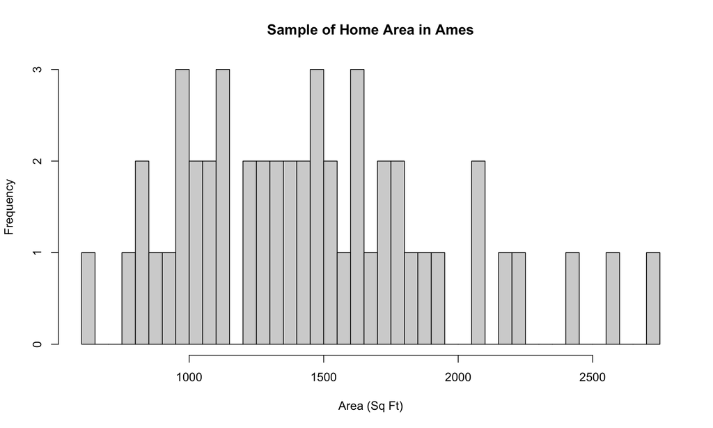

```r
# type your code for the sample statistics and a histogram here
hist(samp1$area, breaks=50, main="Sample of Home Area in Ames", xlab="Area (Sq Ft)")
```

```r
samp1 %>%
  summarise(samp1_mean = mean(area), samp1_med = median(area),
            samp1_sd = sd(area), samp1_iqr = IQR(area),
            samp1_min = min(area), samp1_max = max(area),
            samp1_q1 = quantile(area, 0.25),
            samp1_q3 = quantile(area, 0.75))
```

```
##   samp1_mean samp1_med samp1_sd samp1_iqr samp1_min samp1_max samp1_q1 samp1_q3
## 1    1464.32    1423.5 477.5508    638.25       641      2713   1101.5  1739.75
```

If we’re interested in estimating the average living area in homes in Ames using the sample, our best single guess is the sample mean.

```r
samp1 %>%
  summarise(x_bar = mean(area))
```

```
##     x_bar
## 1 1464.32
```

Depending on which 50 homes you selected, your estimate could be a bit above or a bit below the true population mean of 1,499.69 square feet. In general, though, the sample mean turns out to be a pretty good estimate of the average living area, and we were able to get it by sampling less than 3% of the population.

Let’s take one more sample of size 50, and view the mean area in this sample:

```r
ames %>%
  sample_n(size = 50) %>%
  summarise(x_bar = mean(area))
```

```
##     x_bar
## 1 1496.02
```

Not surprisingly, every time we take another random sample, we get a different sample mean. It’s useful to get a sense of just how much variability we should expect when estimating the population mean this way. The distribution of sample means, called the *sampling distribution*, can help us understand this variability. In this lab, because we have access to the population, we can build up the sampling distribution for the sample mean by repeating the above steps many times. Here we will generate 15,000 samples and compute the sample mean of each. Note that we are sampling with replacement, `replace = TRUE` since sampling distributions are constructed with sampling with replacement.

```r
sample_means50 <- ames %>%
                    rep_sample_n(size = 50, reps = 15000, replace = TRUE) %>%
                    summarise(x_bar = mean(area))
```

Here we use R to take 15,000 samples of size 50 from the population, calculate the mean of each sample, and store each result in a Data Frame called `sample_means50`.

**Q3 (5 pts):** How many rows are there in `sample_means50` and what does each row represent? Describe the sampling distribution, and be sure to specifically note its center vs. the population mean. Make sure to include a histogram of the distribution in your answer.

**Answer:**

```r
# type your code here
#There are 15,000 rows in `sample_means50`. Each row represents the mean of a sample taken from the population. The mean of sample_means50 is extremely close the mean of the overall population.
```

## Interlude: Sampling distributions

The idea behind the `rep_sample_n` function is *repetition*. Earlier we took a single sample of size `n` (50) from the population of all houses in Ames. With this function we are able to repeat this sampling procedure `rep` times in order to build a distribution of a series of sample statistics, which is called the **sampling distribution**.

Note that in practice one rarely gets to build sampling distributions, because we rarely have access to data from the entire population.

Without the `rep_sample_n` function, this would be painful. We would have to manually run and assignment the following code to separate objects *15,000 times*:

```r
ames %>%
  sample_n(size = 50) %>%
  summarise(x_bar = mean(area))
```

Note that for each of the 15,000 times we computed a mean, we did so from a **different** sample!